# Lab 8 Extra

ESS Data Wrangling

# Introduction

First of all, I’m glad you opened this link! Feel free to copy the code for your purposes.

Not all data comes in a neat and clean way. Here I’ll show you how I prepared the data for [Lab 8](https://artur-baranov.github.io/nu-ps405-ds/ps405-d_8.html).

# Turning to Business

As usual, let’s load the library `tidyverse` for data wrangling and `kableExtra` for better display of the results in HTML document.

```r
library(tidyverse)
library(kableExtra)
```

Now, let’s load the raw dataset.

```r
df = read.csv("data_raw/ESS11-subset.csv")
```

Here is how it looks like:

```r
df %>%
  head() %>%
  kable()
```

| name | essround | edition | proddate | idno | cntry | dweight | pspwght | pweight | anweight | pplfair | trstplt | trstprt | happy | rlgdgr | edulvlb | prob | stratum | psu |
| --- | --- | --- | --- | --- | --- | --- | --- | --- | --- | --- | --- | --- | --- | --- | --- | --- | --- | --- |
| ESS11e02 | 11 | 2 | 20.11.2024 | 50014 | AT | 1.1851145 | 0.3928906 | 0.3309145 | 0.1300132 | 5 | 5 | 5 | 8 | 5 | 322 | 0.0005786 | 107 | 317 |
| ESS11e02 | 11 | 2 | 20.11.2024 | 50030 | AT | 0.6098981 | 0.3251533 | 0.3309145 | 0.1075980 | 0 | 1 | 0 | 9 | 0 | 423 | 0.0011244 | 69 | 128 |
| ESS11e02 | 11 | 2 | 20.11.2024 | 50057 | AT | 1.3923296 | 4.0000234 | 0.3309145 | 1.3236659 | 9 | 4 | 4 | 9 | 8 | 610 | 0.0004925 | 18 | 418 |
| ESS11e02 | 11 | 2 | 20.11.2024 | 50106 | AT | 0.5560615 | 0.1762276 | 0.3309145 | 0.0583163 | 6 | 3 | 3 | 7 | 6 | 422 | 0.0012333 | 101 | 295 |
| ESS11e02 | 11 | 2 | 20.11.2024 | 50145 | AT | 0.7227953 | 1.0609399 | 0.3309145 | 0.3510804 | 3 | 5 | 5 | 9 | 1 | 322 | 0.0009488 | 115 | 344 |
| ESS11e02 | 11 | 2 | 20.11.2024 | 50158 | AT | 0.9926053 | 1.3928125 | 0.3309145 | 0.4609019 | 8 | 5 | 5 | 8 | 3 | 313 | 0.0006909 | 7 | 373 |

Take a look on their codebook [here](https://ess.sikt.no/en/). Check how the “`pplfair` - Most people try to take advantage of you, or try to be fair” variable is coded:

| Value | Category |
| --- | --- |
| 0 | Most people try to take advantage of me |
| 1 | 1 |
| 2 | 2 |
| 3 | 3 |
| 4 | 4 |
| 5 | 5 |
| 6 | 6 |
| 7 | 7 |
| 8 | 8 |
| 9 | 9 |
| 10 | Most people try to be fair |
| 77 | Refusal* |
| 88 | Don’t know* |
| 99 | No answer* |

Thus, we need to recode values `77`, `88` and `99` to something else, otherwise our aggregated values can get over 10 when the scale doesn’t assume it. Let’s see:

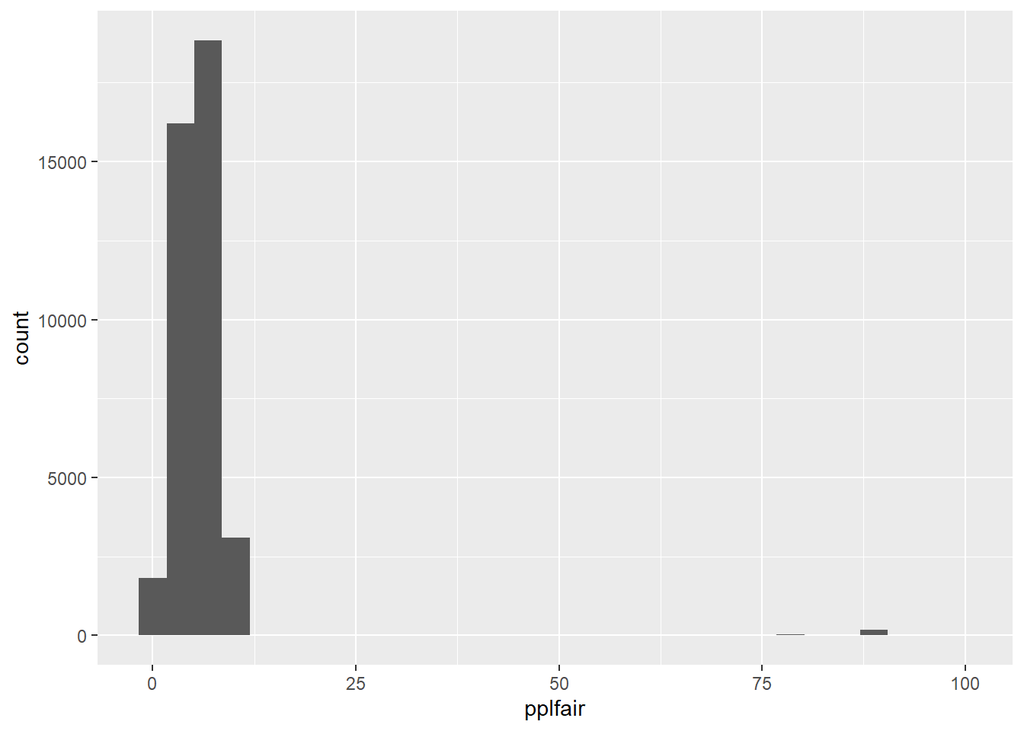

```r
df %>%
  ggplot(aes(x = pplfair)) +
  geom_histogram()
```

Let’s record the average without correcting the data.

```r
avg_raw = mean(df$pplfair)
```

You can see how I recode the variables below using `case_when()` from `tidyverse`. I rely on documentation of the European Social Survey, as you should do too! This weird `NA_real_` makes values simply NA. Syntax is not as straightforward, take some time to understand what’s going on!

```r
df = df %>%
  mutate(pplfair = case_when(pplfair == 99 ~ NA_real_,
                             pplfair == 88 ~ NA_real_,
                             pplfair == 77 ~ NA_real_,
                             TRUE ~ pplfair),
         trstplt = case_when(trstplt == 99 ~ NA_real_,
                             trstplt == 88 ~ NA_real_,
                             trstplt == 77 ~ NA_real_,
                             TRUE ~ trstplt),
         trstprt = case_when(trstprt == 99 ~ NA_real_,
                             trstprt == 88 ~ NA_real_,
                             trstprt == 77 ~ NA_real_,
                             TRUE ~ trstprt),
         rlgdgr = case_when(rlgdgr == 99 ~ NA_real_,
                             rlgdgr == 88 ~ NA_real_,
                             rlgdgr == 77 ~ NA_real_,
                             TRUE ~ rlgdgr),
         happy = case_when(happy == 99 ~ NA_real_,
                             happy == 88 ~ NA_real_,
                             happy == 77 ~ NA_real_,
                             TRUE ~ happy),
         edulvlb = case_when(edulvlb < 610 ~ 1,
                             edulvlb == 610 | edulvlb == 620 ~ 2,
                             edulvlb == 710 | edulvlb == 720 ~ 3,
                             edulvlb == 800 ~ 4,
                             TRUE ~ NA_real_))
```

Now, let’s calculate average. Don’t forget, now we have NAs, so we need to use `na.rm = TRUE` to avoid errors.

```r
avg_corr = mean(df$pplfair, na.rm = TRUE)
```

Now, compare. This might be quite meaningful!

```r
data.frame(`Raw` = avg_raw, `Recoded` = avg_corr) %>%
  kable()
```

| Raw | Recoded |
| --- | --- |
| 6.131985 | 5.708889 |

Now, let’s group the data by country to aggregate variables to the country level.

```r
df_groupped = df %>%
  group_by(cntry) %>%
  summarize(pplfair = mean(pplfair, na.rm = T),
            trstplt = mean(trstplt, na.rm = T),
            trstprt = mean(trstprt, na.rm = T),
            rlgdgr = mean(rlgdgr, na.rm = T),
            happy = mean(happy, na.rm = T),
            edulvlb = mean(edulvlb, na.rm = T))

head(df_groupped) %>%
  kable()
```

| cntry | pplfair | trstplt | trstprt | rlgdgr | happy | edulvlb |
| --- | --- | --- | --- | --- | --- | --- |
| AT | 6.385696 | 3.773544 | 3.723961 | 4.612917 | 7.781570 | 1.243568 |
| BE | 6.076585 | 4.172808 | 3.942565 | 4.145283 | 7.778544 | 1.642675 |
| CH | 6.431571 | 5.540824 | 5.292646 | 4.482909 | 8.154348 | 1.498912 |
| CY | 4.428363 | 2.681481 | 2.497041 | 6.756598 | 6.969118 | 1.469173 |
| DE | 6.177006 | 4.004165 | 3.974069 | 3.922599 | 7.762929 | 1.435993 |
| ES | 5.578890 | 2.784035 | 2.776864 | 4.104518 | 7.847991 | 1.438520 |

Finally, save the data. This is the data we have been working in the Lab 8.

```r
write.csv(df_groupped, "data/ess.csv", row.names = F)
```